# Assignment 9: Visualization - Revealing a graph

*How to do it?*:

- Open the Rmarkdown file of this assignment (link) in Rstudio.
- Right under each **question**, insert a code chunk (you can use the hotkey `Ctrl + Alt + I` to add a code chunk) and code the solution for the question.
- `Knit` the rmarkdown file (hotkey: `Ctrl + Alt + K`) to export an html.
- Publish the html file to your Githiub Page.

*Submission*: Submit the link on Github of the assignment to Canvas

**Notice:** *In this assignment, all the plot should have title, caption, and axis labels.*

1. Use the dataset by of covid 19 by WHO at https://covid19.who.int/WHO-COVID-19-global-data.csv. Find the three countries with the most numbers of deaths by Covid-19.

```r
library(dplyr)

covid <- read.csv("C:/Users/student/Downloads/WHO-COVID-19-global-daily-data.csv")
covid$Date_reported <- as.Date(covid$Date_reported)
top_countries <- covid %>%
  filter(Date_reported == max(Date_reported)) %>%
  arrange(desc(Cumulative_deaths)) %>%
  select(Country, Cumulative_deaths)
head(top_countries, 3)
```

```
##                    Country Cumulative_deaths
## 1 United States of America           1228289
## 2                   Brazil            703536
## 3                    India            533847
```

Hint:

- Use `filter` to select the most current date
- Pipe with `arrange(-Cumulative_deaths)` to rank the data by the number of cumulative deaths
2. Use `transition_reveal` to make a plot revealing the number of deaths in the three countries with the most numbers of deaths

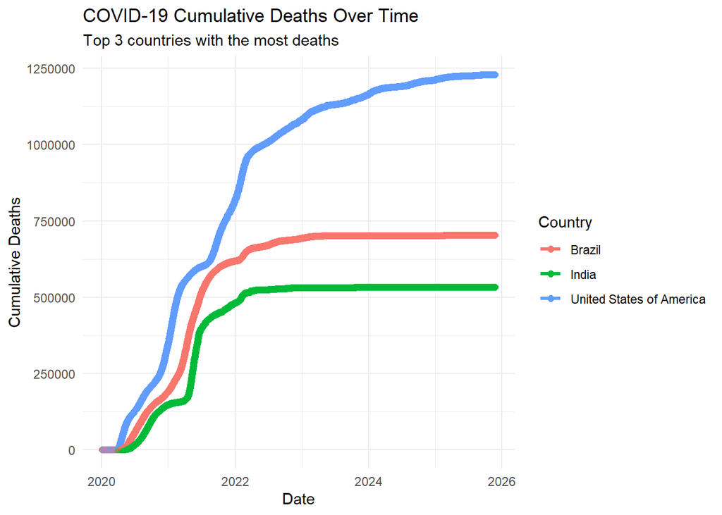

```r
library(dplyr)
library(ggplot2)
covid$Date_reported <- as.Date(covid$Date_reported)
top_countries <- covid %>%
  filter(Date_reported == max(Date_reported)) %>%
  arrange(desc(Cumulative_deaths)) %>%
  slice_head(n = 3) %>%
  pull(Country)
covid_top3 <- covid %>%
  filter(Country %in% top_countries)
ggplot(covid_top3, aes(x = Date_reported, y = Cumulative_deaths, color = Country)) +
  geom_line(size = 1.2) +
  geom_point(size = 2) +
  labs(title = "COVID-19 Cumulative Deaths Over Time",
       subtitle = "Top 3 countries with the most deaths",
       x = "Date", y = "Cumulative Deaths") +
  theme_minimal()
```

3. Create the new variable (column) `death_per_cases` recording the number of deaths per cases (Hint: divide cumulative deaths by cumulative cases). What are the three countries with the highest deaths per cases?

```r
covid <- covid %>%
  mutate(death_per_cases = ifelse(Cumulative_cases > 0,
                                  Cumulative_deaths / Cumulative_cases,
                                  NA))
latest_date <- max(covid$Date_reported)
top_death_rate <- covid %>%
  filter(Date_reported == latest_date) %>%
  arrange(desc(death_per_cases)) %>%
  select(Country, death_per_cases)
head(top_death_rate, 3)
```

```
##                Country death_per_cases
## 1                Yemen      0.18074508
## 2                Sudan      0.07885237
## 3 Syrian Arab Republic      0.05508246
```

4. Use `transition_reveal` to make a plot revealing the number of deaths per cases of the US, Italy and Mexico.

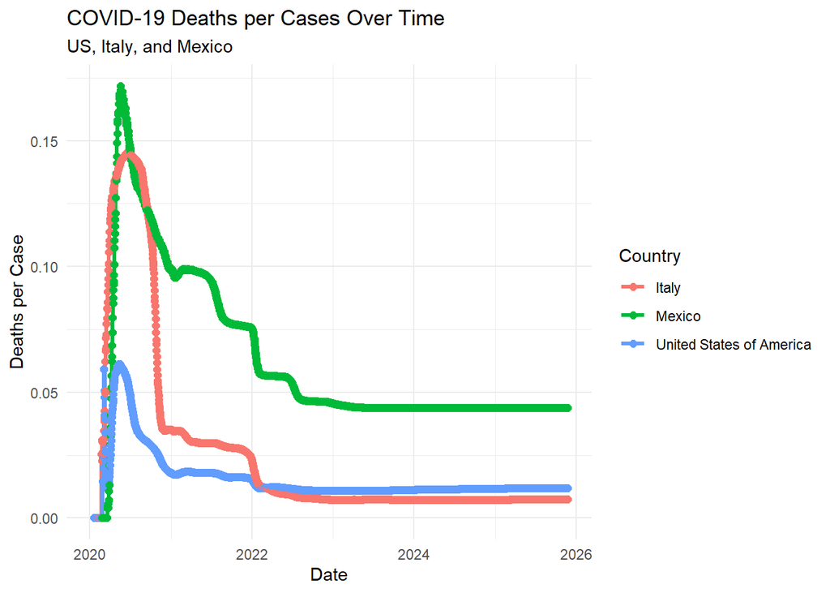

```r
countries_of_interest <- c("United States of America", "Italy", "Mexico")
covid_top3 <- covid %>%
  filter(Country %in% countries_of_interest)
ggplot(covid_top3, aes(x = Date_reported, y = death_per_cases, color = Country)) +
  geom_line(size = 1.2) +
  geom_point(size = 2) +
  labs(title = "COVID-19 Deaths per Cases Over Time",
       subtitle = "US, Italy, and Mexico",
       x = "Date",
       y = "Deaths per Case") +
  theme_minimal()
```

5. Import the following data https://raw.githubusercontent.com/owid/covid-19-data/master/public/data/vaccinations/vaccinations.csv

Use `transition_reveal` to plot the total vaccinations per hundred by level of income. Hint: the levels of income are identified in the `location` variable. Put a short comment on the caption of the plot.

[figure not shown]

```r
covid2 <- read.csv("https://raw.githubusercontent.com/owid/covid-19-data/master/public/data/vaccinations/vaccinations.csv")
covid2$date <- as.Date(covid2$date)
vacc_by_income <- covid2 %>%
  group_by(date, location) %>%
  summarise(total_vacc_per_hundred = sum(total_vaccinations_per_hundred, na.rm = TRUE))
ggplot(vacc_by_income, aes(x = date, y = total_vacc_per_hundred, color = location)) +
  geom_line(size = 1.2) +
  geom_point(size = 2) +
  labs(title = "COVID-19 Total Vaccinations per Hundred by Income Level",
       caption = "Observation: Higher-income countries reached higher vaccination rates faster.",
       x = "Date",
       y = "Total Vaccinations per Hundred") +
  theme_minimal()
```